# Population-Weighted Maternal Health Coverage Analysis

Comparing On-Track vs Off-Track Countries for SDG 3.1

_

2025-07-29

**Positions Applied For:** - Household Survey Data Analyst Consultant - Req. #581656 - Microdata Harmonization Consultant – Req. #581699

## Executive Summary

This analysis compares population-weighted maternal health coverage between countries that are **on-track** versus **off-track** for achieving SDG 3.1 (reducing maternal mortality). Using 2022 projected births as weights, we examine coverage gaps in **Antenatal Care (ANC4)** and **Skilled Birth Attendance (SBA)**.

## Data and Methodology

The analysis combines three key datasets: - **UNICEF maternal health indicators** (ANC4 and SBA coverage, 2018-2022) - **UN World Population Prospects 2022** (projected births for 2022 as weights) - **SDG 3.1 country classifications** (on-track vs off-track status)

Population-weighted averages ensure that countries with larger populations have proportional influence on the results, providing a more accurate global picture.

```r
# Load the analysis results
weighted_coverage <- read_csv("../04_output/population_weighted_coverage.csv")
merged_df <- read_csv("../04_output/merged_data.csv")

# Display data summary
kable(weighted_coverage,
      caption = "Population-Weighted Maternal Health Coverage by Track Status",
      digits = 1)
```

Population-Weighted Maternal Health Coverage by Track Status

| track_status | anc4_weighted_avg | anc4_countries | sba_weighted_avg | sba_countries | total_countries | total_births_2022 | total_births_millions |
| --- | --- | --- | --- | --- | --- | --- | --- |
| off-track | 55.3 | 42 | 68.7 | 44 | 52 | 57892666 | 57.9 |
| on-track | 72.8 | 44 | 92.5 | 105 | 120 | 76100366 | 76.1 |

## Key Findings

```r
# Calculate coverage gaps
on_track <- weighted_coverage[weighted_coverage$track_status == "on-track", ]
off_track <- weighted_coverage[weighted_coverage$track_status == "off-track", ]

anc4_gap <- round(on_track$anc4_weighted_avg - off_track$anc4_weighted_avg, 1)
sba_gap <- round(on_track$sba_weighted_avg - off_track$sba_weighted_avg, 1)
```

- **ANC4 Coverage Gap**: 17.5 percentage points (On-track: 72.8% vs Off-track: 55.3%)
- **SBA Coverage Gap**: 23.8 percentage points (On-track: 92.5% vs Off-track: 68.7%)

## Visualization: Coverage Comparison

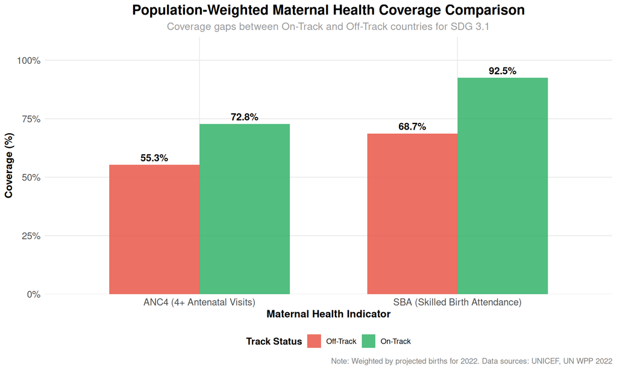

Population-Weighted Maternal Health Coverage: On-Track vs Off-Track Countries

```r
# Prepare data for visualization
plot_data <- weighted_coverage %>%
  select(track_status, anc4_weighted_avg, sba_weighted_avg) %>%
  pivot_longer(cols = c(anc4_weighted_avg, sba_weighted_avg),
               names_to = "indicator",
               values_to = "coverage") %>%
  mutate(
    indicator = case_when(
      indicator == "anc4_weighted_avg" ~ "ANC4 (4+ Antenatal Visits)",
      indicator == "sba_weighted_avg" ~ "SBA (Skilled Birth Attendance)"
    ),
    track_status = stringr::str_to_title(track_status)
  )

# Create the main comparison chart
p1 <- ggplot(plot_data, aes(x = indicator, y = coverage, fill = track_status)) +
  geom_col(position = "dodge", width = 0.7, alpha = 0.8) +
  geom_text(aes(label = paste0(coverage, "%")),
            position = position_dodge(width = 0.7),
            vjust = -0.5, size = 4, fontface = "bold") +
  scale_fill_manual(values = c("Off-Track" = "#e74c3c", "On-Track" = "#27ae60"),
                    name = "Track Status") +
  scale_y_continuous(limits = c(0, 100),
                     labels = function(x) paste0(x, "%"),
                     expand = expansion(mult = c(0, 0.1))) +
  labs(
    title = "Population-Weighted Maternal Health Coverage Comparison",
    subtitle = "Coverage gaps between On-Track and Off-Track countries for SDG 3.1",
    x = "Maternal Health Indicator",
    y = "Coverage (%)",
    caption = "Note: Weighted by projected births for 2022. Data sources: UNICEF, UN WPP 2022"
  ) +
  theme_minimal() +
  theme(
    plot.title = element_text(size = 16, face = "bold", hjust = 0.5),
    plot.subtitle = element_text(size = 12, hjust = 0.5, color = "gray60"),
    legend.position = "bottom",
    legend.title = element_text(face = "bold"),
    axis.text = element_text(size = 11),
    axis.title = element_text(size = 12, face = "bold"),
    panel.grid.minor = element_blank(),
    plot.caption = element_text(size = 9, color = "gray50")
  )

print(p1)
```

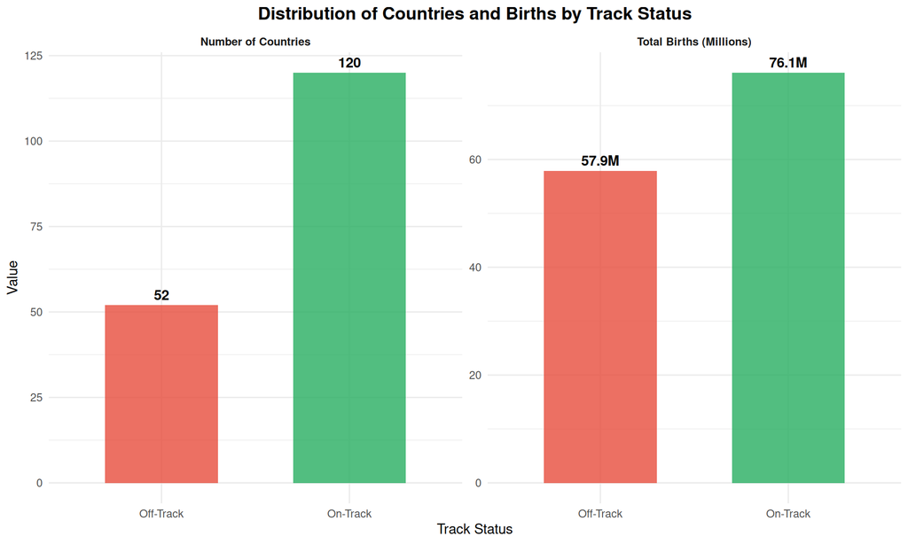

Country and Birth Distribution by Track Status

```r
# Additional visualization showing country and birth distribution
dist_data <- weighted_coverage %>%
  select(track_status, total_countries, total_births_millions) %>%
  pivot_longer(cols = c(total_countries, total_births_millions),
               names_to = "metric", values_to = "value") %>%
  mutate(
    metric = case_when(
      metric == "total_countries" ~ "Number of Countries",
      metric == "total_births_millions" ~ "Total Births (Millions)"
    ),
    track_status = stringr::str_to_title(track_status)
  )

p2 <- ggplot(dist_data, aes(x = track_status, y = value, fill = track_status)) +
  geom_col(alpha = 0.8, width = 0.6) +
  geom_text(aes(label = ifelse(grepl("Countries", metric),
                              as.character(value),
                              paste0(value, "M"))),
            vjust = -0.5, fontface = "bold") +
  facet_wrap(~metric, scales = "free_y") +
  scale_fill_manual(values = c("Off-Track" = "#e74c3c", "On-Track" = "#27ae60")) +
  labs(
    title = "Distribution of Countries and Births by Track Status",
    x = "Track Status", y = "Value"
  ) +
  theme_minimal() +
  theme(
    plot.title = element_text(size = 14, face = "bold", hjust = 0.5),
    legend.position = "none",
    strip.text = element_text(face = "bold")
  )

print(p2)
```

## Detailed Results Table

```r
# Create a comprehensive results table
results_table <- weighted_coverage %>%
  select(track_status, anc4_weighted_avg, sba_weighted_avg,
         total_countries, total_births_millions) %>%
  mutate(track_status = stringr::str_to_title(track_status))

kable(results_table,
      col.names = c("Track Status", "ANC4 Weighted (%)", "SBA Weighted (%)",
                    "Total Countries", "Total Births (M)"),
      caption = "Population-Weighted Coverage Analysis by Track Status",
      digits = 1)
```

Population-Weighted Coverage Analysis by Track Status

| Track Status | ANC4 Weighted (%) | SBA Weighted (%) | Total Countries | Total Births (M) |
| --- | --- | --- | --- | --- |
| Off-Track | 55.3 | 68.7 | 52 | 57.9 |
| On-Track | 72.8 | 92.5 | 120 | 76.1 |

## Interpretation and Key Insights

The analysis reveals significant disparities in maternal health coverage between countries on-track and off-track for achieving SDG 3.1:

**Coverage Gaps**: Off-track countries demonstrate substantially lower population-weighted coverage for both indicators. The ANC4 gap of 17.5 percentage points and SBA gap of 23.8 percentage points highlight the maternal health challenges in countries struggling with high maternal mortality rates.

**Population Impact**: The population-weighted approach reveals the true global burden, as it accounts for the number of women and births affected. Countries with larger populations have proportional influence on the results, providing a more accurate picture of worldwide maternal health access.

**Policy Implications**: The coverage gaps underscore the need for targeted interventions in off-track countries, particularly focusing on improving antenatal care access and ensuring skilled attendance at birth.

### Caveats and Assumptions

1. **Data Availability**: Coverage estimates represent the most recent data available for each country (2018-2022), which may not reflect current conditions in all cases.
2. **Population Weights**: Analysis uses UN 2022 projected births as weights, assuming these projections accurately represent the target population for maternal health services.
3. **Country Classifications**: SDG 3.1 track status is based on progress toward maternal mortality reduction targets, which may not perfectly correlate with service coverage patterns.
4. **Missing Data**: Countries without complete data for track status, birth projections, or coverage indicators were excluded from the analysis, potentially affecting representativeness.
5. **Temporal Alignment**: Coverage data spans 2018-2022 while using 2022 birth projections as weights, assuming coverage patterns remain relatively stable within this timeframe.

## Conclusions

This analysis demonstrates clear maternal health coverage disparities between countries on different trajectories for SDG 3.1 achievement. The population-weighted approach provides valuable insights into the global burden of inadequate maternal health access, highlighting the urgent need for targeted interventions in off-track countries to ensure equitable progress toward universal health coverage.

*Report generated on 2025-07-29 using R Markdown*